# Temperature time-series Analysis

Kim sung don

2021 2 16

기온 데이터 시계열 분석

데이터 불러오기

사용 PC환경에 맞춰서 경로를 설정해주시면 됩니다.  
각 변수별 요약통계량을 확인할 수 있습니다.

```r
temp_data <- read.csv('C:\\Users\\a3011\\Downloads\\temper\\GlobalLandTemperaturesByCountry.csv')
summary(temp_data)
```

```
##       dt            AverageTemperature AverageTemperatureUncertainty
##  Length:577462      Min.   :-37.66     Min.   : 0.05
##  Class :character   1st Qu.: 10.03     1st Qu.: 0.32
##  Mode  :character   Median : 20.90     Median : 0.57
##                     Mean   : 17.19     Mean   : 1.02
##                     3rd Qu.: 25.81     3rd Qu.: 1.21
##                     Max.   : 38.84     Max.   :15.00
##                     NA's   :32651      NA's   :31912
##    Country
##  Length:577462
##  Class :character
##  Mode  :character
##
##
##
##
```

날짜변수가 character(문자열)임으로 날짜 속성으로 변경합니다.

```r
temp_data$dt<-as.Date(temp_data$dt,format="%Y-%m-%d")
```

한국 기온 데이터만 추출합니다.

```r
ko_temper<-subset(temp_data, Country=='South Korea')
head(ko_temper)
```

```
##                dt AverageTemperature AverageTemperatureUncertainty     Country
## 488388 1841-01-01             -3.677                         2.670 South Korea
## 488389 1841-02-01             -1.420                         1.998 South Korea
## 488390 1841-03-01              2.849                         2.006 South Korea
## 488391 1841-04-01              9.675                         2.254 South Korea
## 488392 1841-05-01             15.345                         1.813 South Korea
## 488393 1841-06-01             19.360                         3.199 South Korea
```

1980년대부터 기온 데이터를 사용함으로 데이터를 추출해줍니다.

```r
ko_temper<-subset(ko_temper,dt>=as.Date('1980-1-1',format='%Y-%m-%d'))
```

데이터의 분포를 살펴봅니다.

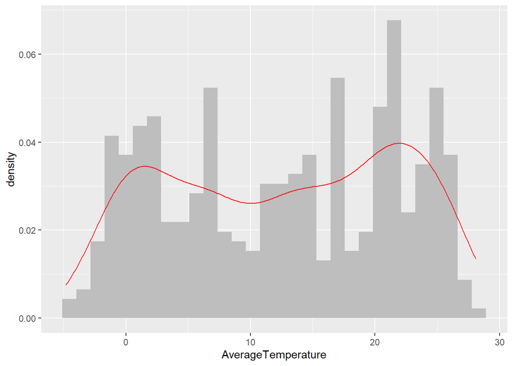

```r
options(repr.plot.width=4, repr.plot.height=4)
ggplot(ko_temper,aes(x=AverageTemperature))+geom_histogram(aes(y=..density..),fill="grey")+geom_density(col="red")
```

추세와 계절성을 확인합니다.

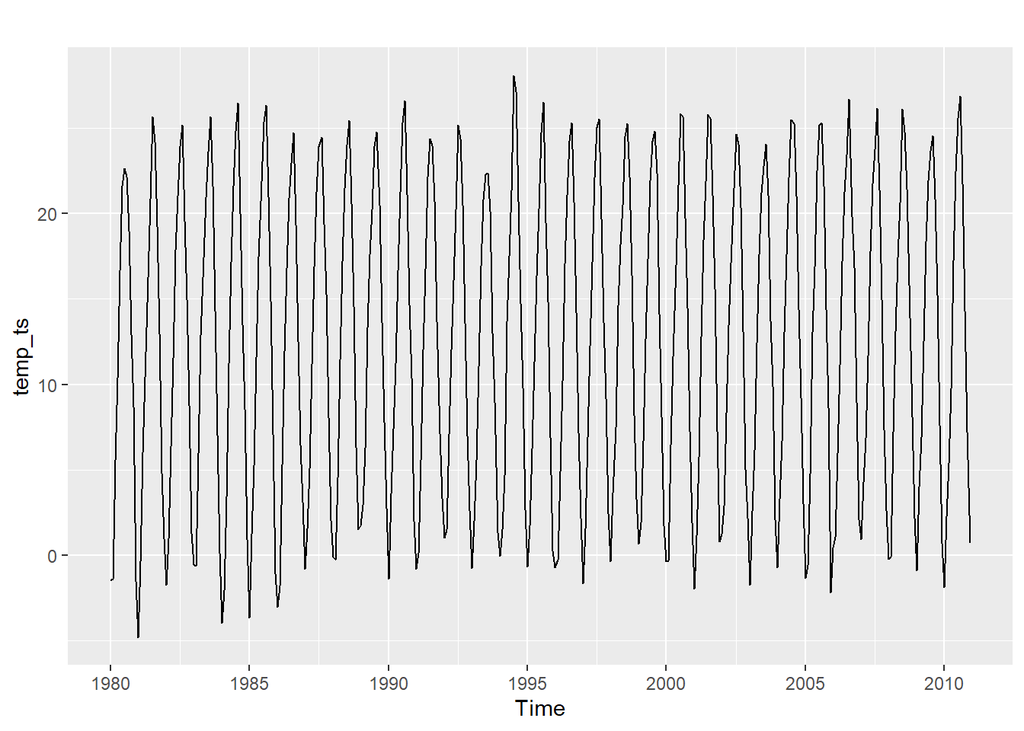

```r
options(repr.plot.width=5, repr.plot.height=5)
temp_ts<-ts(ko_temper[,2],start=c(1980,1),end=c(2010,12),frequency=12)
autoplot(temp_ts)
```

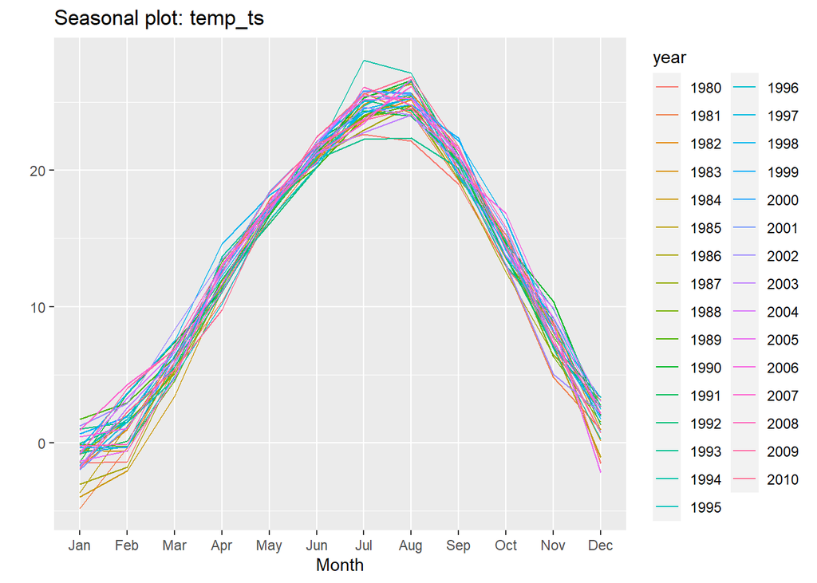

```r
ggseasonplot(temp_ts)
```

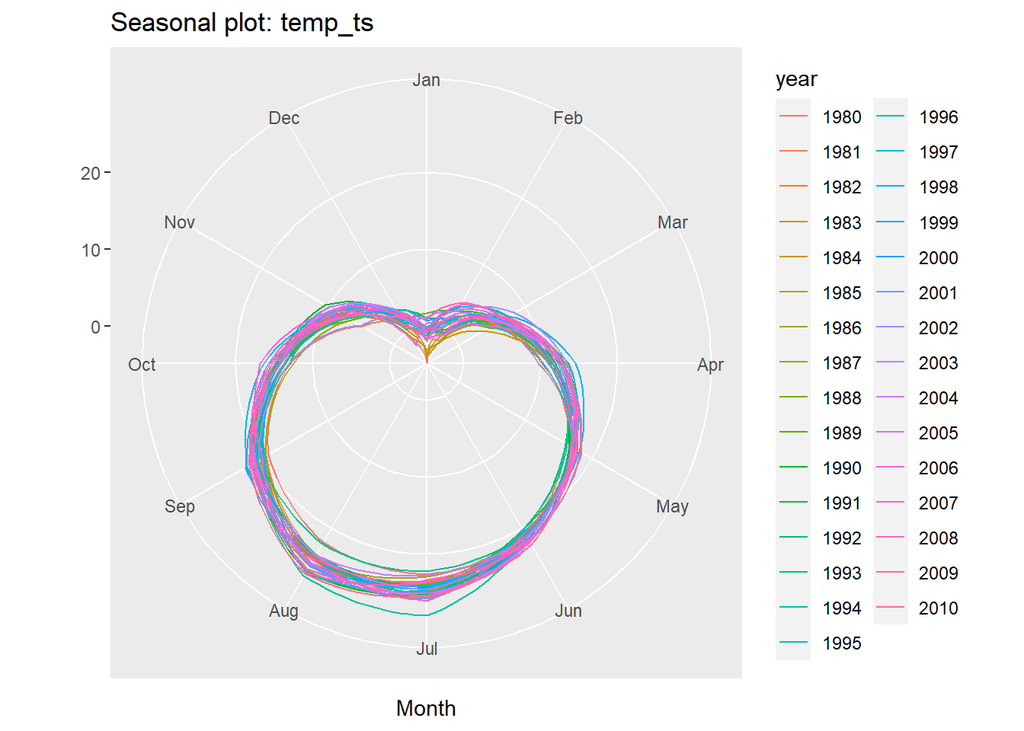

```r
ggseasonplot(temp_ts,polar=TRUE)
```

두 그래프를 보게되면 계절성이 뚜렷한 것을 확인할 수 있습니다.(주기 12 예상)

주기별 데이터의 형태를 확인합니다.

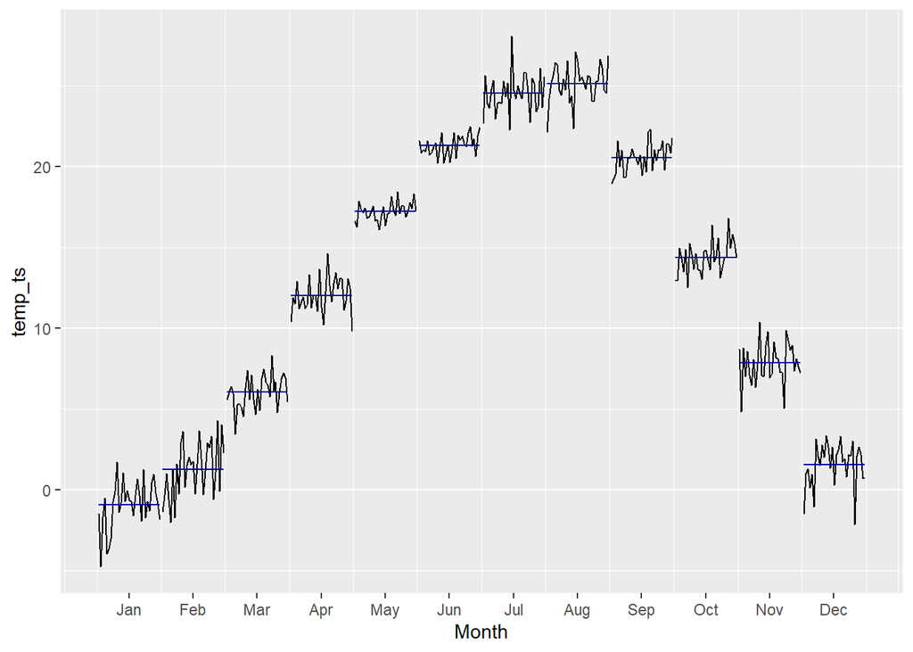

```r
ggsubseriesplot(temp_ts)
```

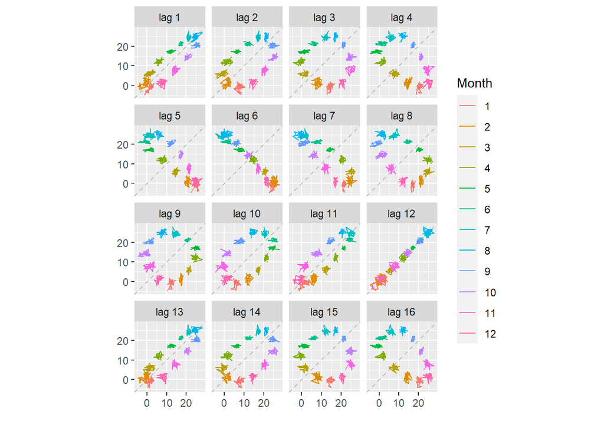

```r
gglagplot(temp_ts)
```

시차 그래프를 본 결과 lag12일때 가장 적합하다는 것을 알 수 있습니다.

ACF에서도 뚜렷한 계절성을 가지는 것을 확인할 수 있습니다.

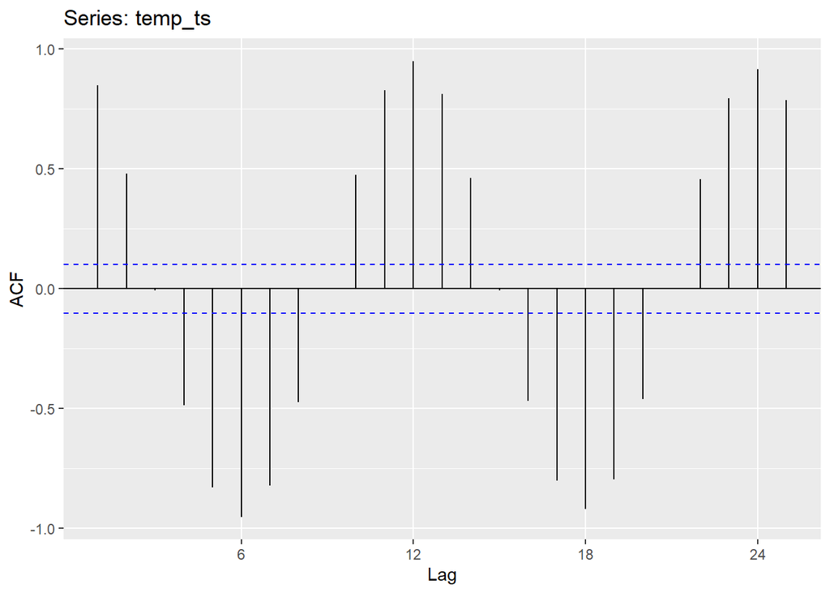

```r
ggAcf(temp_ts)
```

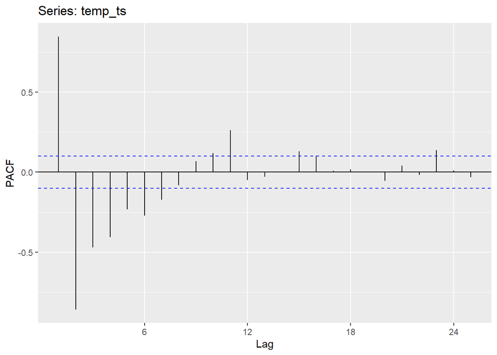

```r
ggPacf(temp_ts)
```

계절성이 뚜렷하고 ACF,PACF 그래프를 보면 계절-ARIMA 모형을 사용하는 것이 적절해 보인다.

단위근 검정(Dickey-Fuller)

```r
adf.test(temp_ts,k=0)
```

```
##
##  Augmented Dickey-Fuller Test
##
## data:  temp_ts
## Dickey-Fuller = -5.4148, Lag order = 0, p-value = 0.01
## alternative hypothesis: stationary
```

p-value가 0.05보다 작음으로 정상시계열이다.

seasonal naive method 사용
$$\hat{y}_{T+h|T} = y_{T+h-m(k+1)}$$
$m =$계절성분(m=12)
training한 마지막 달의 값들을 그대로 가져쓰는 방식이다. 신뢰구간안에 값이 포함되는지 확인할 때 쓰시면됩니다.

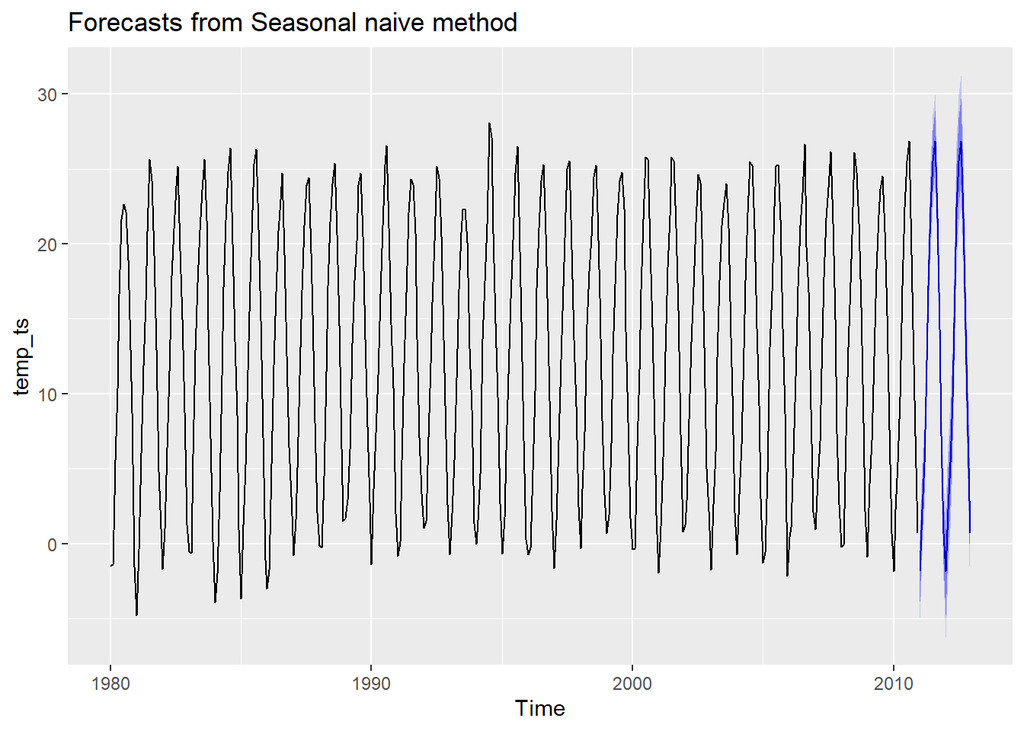

```r
temp_fc<-snaive(temp_ts,h=24)
autoplot(temp_fc)
```

```r
summary(temp_fc)
```

```
##
## Forecast method: Seasonal naive method
##
## Model Information:
## Call: snaive(y = temp_ts, h = 24)
##
## Residual sd: 1.5849
##
## Error measures:
##                      ME     RMSE      MAE      MPE     MAPE MASE      ACF1
## Training set 0.04587222 1.584852 1.224039 14.52852 72.45772    1 0.2280361
##
## Forecasts:
##          Point Forecast      Lo 80      Hi 80      Lo 95     Hi 95
## Jan 2011         -1.852 -3.8830692  0.1790692 -4.9582523  1.254252
## Feb 2011          2.267  0.2359308  4.2980692 -0.8392523  5.373252
## Mar 2011          5.409  3.3779308  7.4400692  2.3027477  8.515252
## Apr 2011          9.766  7.7349308 11.7970692  6.6597477 12.872252
## May 2011         17.223 15.1919308 19.2540692 14.1167477 20.329252
## Jun 2011         22.452 20.4209308 24.4830692 19.3457477 25.558252
## Jul 2011         25.562 23.5309308 27.5930692 22.4557477 28.668252
## Aug 2011         26.863 24.8319308 28.8940692 23.7567477 29.969252
## Sep 2011         21.748 19.7169308 23.7790692 18.6417477 24.854252
## Oct 2011         14.310 12.2789308 16.3410692 11.2037477 17.416252
## Nov 2011          7.219  5.1879308  9.2500692  4.1127477 10.325252
## Dec 2011          0.710 -1.3210692  2.7410692 -2.3962523  3.816252
## Jan 2012         -1.852 -4.7243656  1.0203656 -6.2449041  2.540904
## Feb 2012          2.267 -0.6053656  5.1393656 -2.1259041  6.659904
## Mar 2012          5.409  2.5366344  8.2813656  1.0160959  9.801904
## Apr 2012          9.766  6.8936344 12.6383656  5.3730959 14.158904
## May 2012         17.223 14.3506344 20.0953656 12.8300959 21.615904
## Jun 2012         22.452 19.5796344 25.3243656 18.0590959 26.844904
## Jul 2012         25.562 22.6896344 28.4343656 21.1690959 29.954904
## Aug 2012         26.863 23.9906344 29.7353656 22.4700959 31.255904
## Sep 2012         21.748 18.8756344 24.6203656 17.3550959 26.140904
## Oct 2012         14.310 11.4376344 17.1823656  9.9170959 18.702904
## Nov 2012          7.219  4.3466344 10.0913656  2.8260959 11.611904
## Dec 2012          0.710 -2.1623656  3.5823656 -3.6829041  5.102904
```

잔차와 융검정

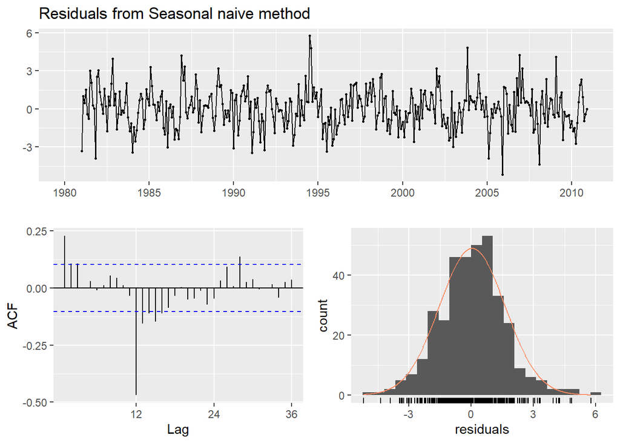

```
##
##  Ljung-Box test
##
## data:  Residuals from Seasonal naive method
## Q* = 147.01, df = 24, p-value < 2.2e-16
##
## Model df: 0.   Total lags used: 24
```

```r
checkresiduals(temp_fc)
```

auto.arima를 활용한 forecasting

```r
fit<-auto.arima(temp_ts,lambda=0)
```

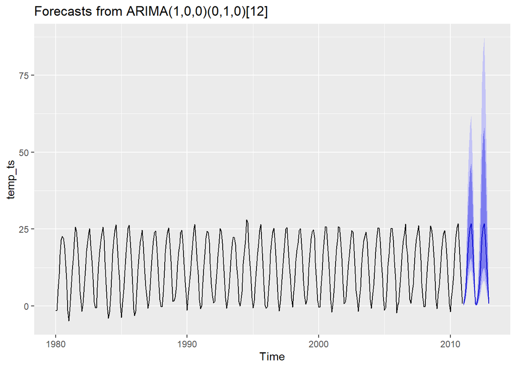

```r
fit %>%forecast(h=24)%>%autoplot()
```

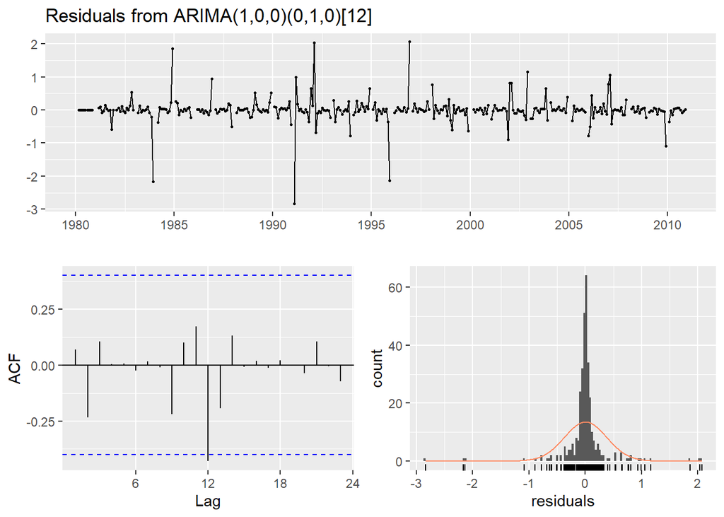

```
##
##  Ljung-Box test
##
## data:  Residuals from ARIMA(1,0,0)(0,1,0)[12]
## Q* = 150.06, df = 23, p-value < 2.2e-16
##
## Model df: 1.   Total lags used: 24
```

```r
checkresiduals(fit)
```

```r
temp_test<-ts(ko_temper[,2],start=c(1980,1),end=c(2012,12),frequency=12)
test <- rev(rev(temp_test)[1:24])
```

평균제곱근오차(RMSE)를 사용해 모형의 성능을 측정합니다. 0에 가까울수록 성능이 좋습니다.

```r
sqrt(sum((test-c(forecast(fit, h = 24)[["mean"]]))^2))
```

```
## [1] 8.876866
```

```r
sqrt(sum((test-c(temp_fc[['mean']]))^2))
```

```
## [1] 7.468721
```

데이터별 신뢰구간안에 잘 들어가는지 확인해봅니다.

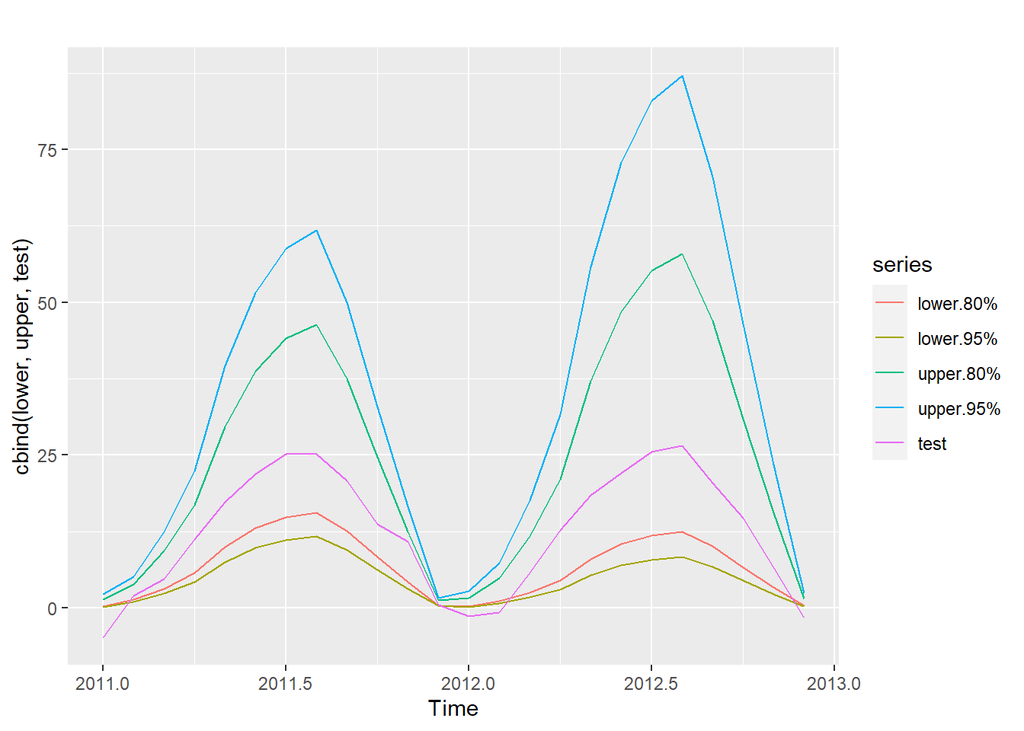

```r
lower<-forecast(fit,h=24)[['lower']]
upper<-forecast(fit,h=24)[['upper']]
autoplot(cbind(lower,upper,test))
```

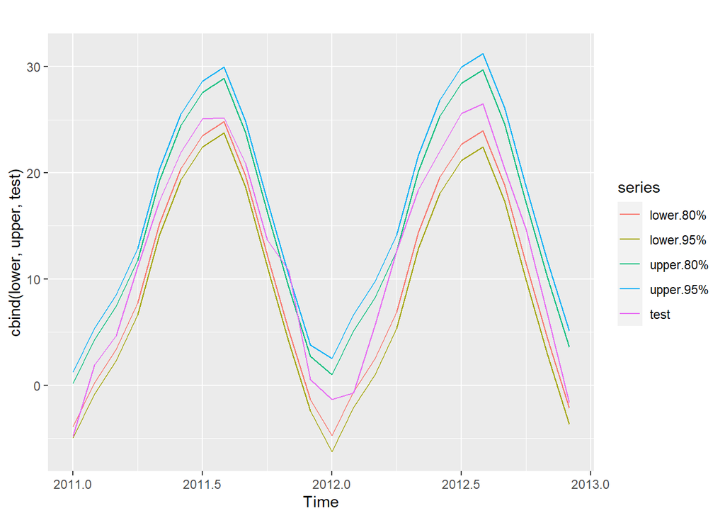

```r
lower<-temp_fc[['lower']]
upper<-temp_fc[['upper']]
autoplot(cbind(lower,upper,test))
```

### 실습 두번쨰 사망률 데이터 분석

데이터의 Dashboard를 보고 75세이상의 10만명당 사망비율이 크게 나타나는 것을 확인할 수 있습니다.  
그래서 이번 분석대상은 75세이상 한국국적 여성과 남성의 사망율을 볼 것입니다.

데이터를 불러오고 첫번째 변수명을 수정해줍니다.

```r
dt=read.csv('D:\\경남연구원세미나자료\\suicide.csv')
names(dt)[1]='country'
head(dt)
```

```
##   country year    sex         age suicides_no population suicides.100k.pop
## 1 Albania 1987   male 15-24 years          21     312900              6.71
## 2 Albania 1987   male 35-54 years          16     308000              5.19
## 3 Albania 1987 female 15-24 years          14     289700              4.83
## 4 Albania 1987   male   75+ years           1      21800              4.59
## 5 Albania 1987   male 25-34 years           9     274300              3.28
## 6 Albania 1987 female   75+ years           1      35600              2.81
##   country.year HDI.for.year gdp_for_year.... gdp_per_capita....      generation
## 1  Albania1987           NA    2,156,624,900                796    Generation X
## 2  Albania1987           NA    2,156,624,900                796          Silent
## 3  Albania1987           NA    2,156,624,900                796    Generation X
## 4  Albania1987           NA    2,156,624,900                796 G.I. Generation
## 5  Albania1987           NA    2,156,624,900                796         Boomers
## 6  Albania1987           NA    2,156,624,900                796 G.I. Generation
```

한국국적만 추출합니다.

```r
ko_suicide<-subset(dt,country=='Republic of Korea')
```

한국국적에서 75세이상만 추출합니다.

```r
ko_age_suicide<-subset(ko_suicide,age=='75+ years')
```

한국국적에서 75세이상 남성과 여성을 분리하여 불러옵니다.

```r
ko_male_suicide<-subset(ko_age_suicide,sex=='male')
ko_female_suicide<-subset(ko_age_suicide,sex=='female')
```

불러온 데이터를 확인합니다.

```r
head(ko_male_suicide)
```

```
##                 country year  sex       age suicides_no population
## 20231 Republic of Korea 1985 male 75+ years          42     154800
## 20243 Republic of Korea 1986 male 75+ years          59     160500
## 20255 Republic of Korea 1987 male 75+ years          44     163700
## 20267 Republic of Korea 1988 male 75+ years          44     179000
## 20279 Republic of Korea 1989 male 75+ years          59     186600
## 20291 Republic of Korea 1990 male 75+ years          53     194400
##       suicides.100k.pop          country.year HDI.for.year gdp_for_year....
## 20231             27.13 Republic of Korea1985           NA  100,273,097,170
## 20243             36.76 Republic of Korea1986           NA  115,537,126,326
## 20255             26.88 Republic of Korea1987           NA  146,133,338,196
## 20267             24.58 Republic of Korea1988           NA  196,964,195,387
## 20279             31.62 Republic of Korea1989           NA  243,526,047,717
## 20291             27.26 Republic of Korea1990           NA  279,349,355,714
##       gdp_per_capita....      generation
## 20231               2731 G.I. Generation
## 20243               3078 G.I. Generation
## 20255               3834 G.I. Generation
## 20267               5089 G.I. Generation
## 20279               6217 G.I. Generation
## 20291               7056 G.I. Generation
```

```r
head(ko_female_suicide)
```

```
##                 country year    sex       age suicides_no population
## 20236 Republic of Korea 1985 female 75+ years          38     370700
## 20248 Republic of Korea 1986 female 75+ years          30     378000
## 20260 Republic of Korea 1987 female 75+ years          30     389400
## 20271 Republic of Korea 1988 female 75+ years          47     412300
## 20283 Republic of Korea 1989 female 75+ years          46     429800
## 20295 Republic of Korea 1990 female 75+ years          52     450100
##       suicides.100k.pop          country.year HDI.for.year gdp_for_year....
## 20236             10.25 Republic of Korea1985           NA  100,273,097,170
## 20248              7.94 Republic of Korea1986           NA  115,537,126,326
## 20260              7.70 Republic of Korea1987           NA  146,133,338,196
## 20271             11.40 Republic of Korea1988           NA  196,964,195,387
## 20283             10.70 Republic of Korea1989           NA  243,526,047,717
## 20295             11.55 Republic of Korea1990           NA  279,349,355,714
##       gdp_per_capita....      generation
## 20236               2731 G.I. Generation
## 20248               3078 G.I. Generation
## 20260               3834 G.I. Generation
## 20271               5089 G.I. Generation
## 20283               6217 G.I. Generation
## 20295               7056 G.I. Generation
```

75세이상 남성과 여성은 비슷한 추세를 보이며, 2001년부터 급격하게 상승하는 자살률을 확인할 수 있습니다.

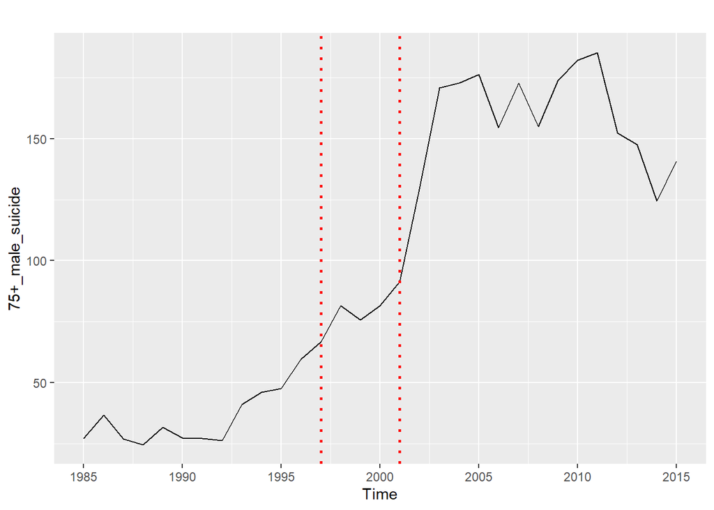

```r
male_suicide<-ts(ko_male_suicide$suicides.100k.pop,start =1985,frequency=1)
female_suicide<-ts(ko_female_suicide$suicides.100k.pop,start=1985,frequency=1)
autoplot(male_suicide,ylab = '75+_male_suicide')+geom_vline(xintercept=c(1997,2001), linetype = 'dotted', color='red', size = 1)
```

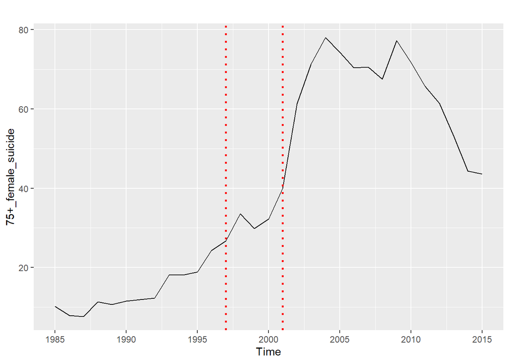

```r
autoplot(female_suicide,ylab = '75+_female_suicide')+geom_vline(xintercept=c(1997,2001), linetype = 'dotted', color='red', size = 1)
```

상관분석 75세 인구가 늘어남에 따라 자살율도 함께올라가는 것을 확인할 수 있으며

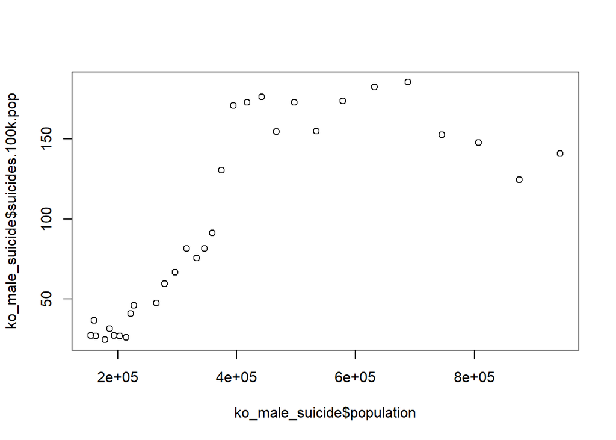

```r
plot(ko_male_suicide$population,ko_male_suicide$suicides.100k.pop)
```

```r
cor(ko_male_suicide$suicides.100k.pop,ko_male_suicide$population)
```

```
## [1] 0.7714776
```

```r
cor(ko_male_suicide$suicides.100k.pop,ko_male_suicide$gdp_per_capita....)
```

```
## [1] 0.8370883
```

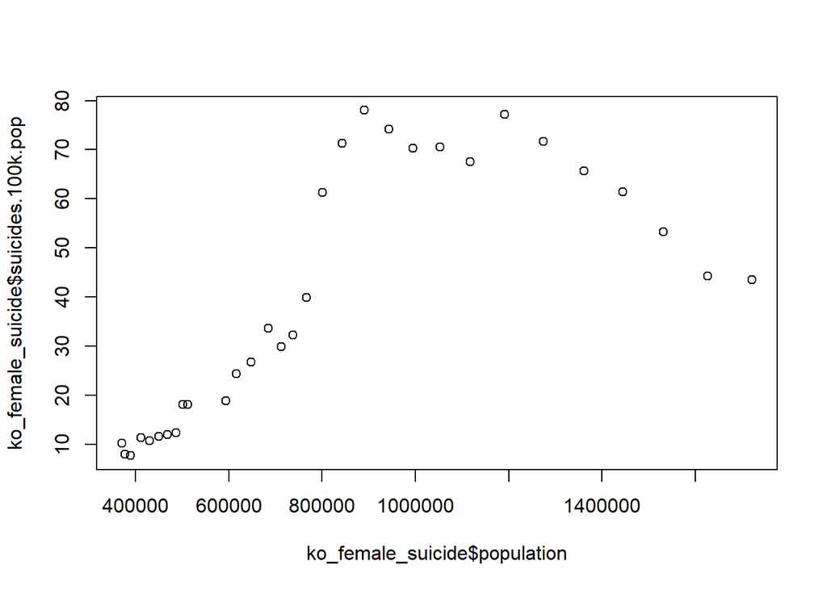

```r
plot(ko_female_suicide$population,ko_female_suicide$suicides.100k.pop)
```

```r
cor(ko_female_suicide$suicides.100k.pop,ko_female_suicide$population)
```

```
## [1] 0.7209176
```

```r
cor(ko_female_suicide$suicides.100k.pop,ko_female_suicide$gdp_per_capita....)
```

```
## [1] 0.7661767
```

```r
adf.test(male_suicide)
```

```
##
##  Augmented Dickey-Fuller Test
##
## data:  male_suicide
## Dickey-Fuller = -0.92905, Lag order = 3, p-value = 0.9329
## alternative hypothesis: stationary
```

```r
adf.test(female_suicide)
```

```
##
##  Augmented Dickey-Fuller Test
##
## data:  female_suicide
## Dickey-Fuller = -0.92919, Lag order = 3, p-value = 0.9329
## alternative hypothesis: stationary
```

두 데이터 모두 비정상 시계열임을 확인할 수 있습니다.

정상 시계열로 바꿔주기 위해 log 변환을 해줍니다.

```r
log_ma_suicide<-log(male_suicide)
log_fe_suicide<-log(female_suicide)
```

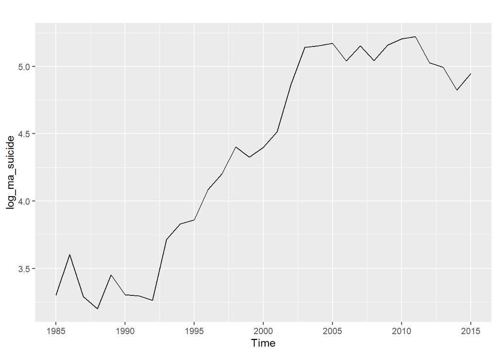

```r
autoplot(log_ma_suicide)
```

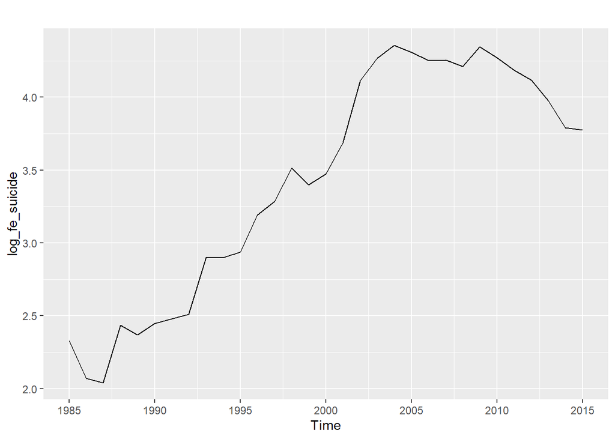

```r
autoplot(log_fe_suicide)
```

```r
adf.test(log_ma_suicide)
```

```
##
##  Augmented Dickey-Fuller Test
##
## data:  log_ma_suicide
## Dickey-Fuller = -0.4889, Lag order = 3, p-value = 0.9762
## alternative hypothesis: stationary
```

```r
adf.test(log_fe_suicide)
```

```
##
##  Augmented Dickey-Fuller Test
##
## data:  log_fe_suicide
## Dickey-Fuller = 0.13474, Lag order = 3, p-value = 0.99
## alternative hypothesis: stationary
```

log변환을 하여도 정상시계열이 되지 않습니다. 평균을 정상화 시키기 위해 차분을 적용합니다.

차분을 1회 진행합니다.

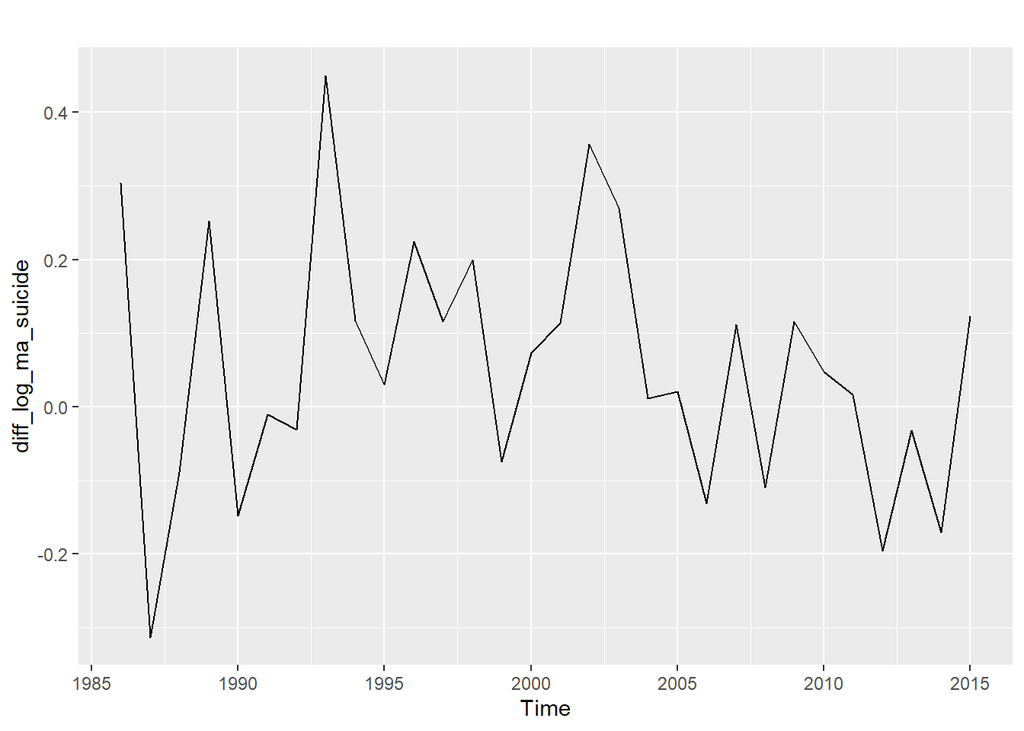

```r
diff_log_ma_suicide <- diff(log_ma_suicide,differences=1)
diff_log_fe_suicide <- diff(log_fe_suicide,differences=1)
autoplot(diff_log_ma_suicide)
```

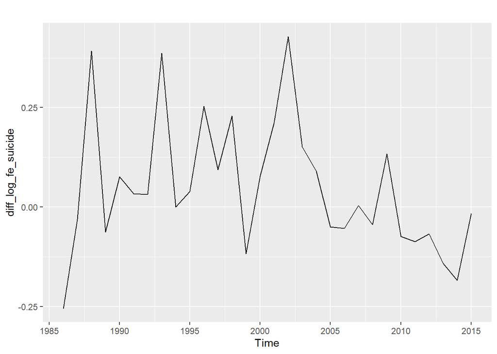

```r
autoplot(diff_log_fe_suicide)
```

```r
adf.test(diff_log_ma_suicide)
```

```
##
##  Augmented Dickey-Fuller Test
##
## data:  diff_log_ma_suicide
## Dickey-Fuller = -2.066, Lag order = 3, p-value = 0.5473
## alternative hypothesis: stationary
```

```r
adf.test(diff_log_fe_suicide)
```

```
##
##  Augmented Dickey-Fuller Test
##
## data:  diff_log_fe_suicide
## Dickey-Fuller = -2.7441, Lag order = 3, p-value = 0.2868
## alternative hypothesis: stationary
```

차분을 1회 더 시행합니다.

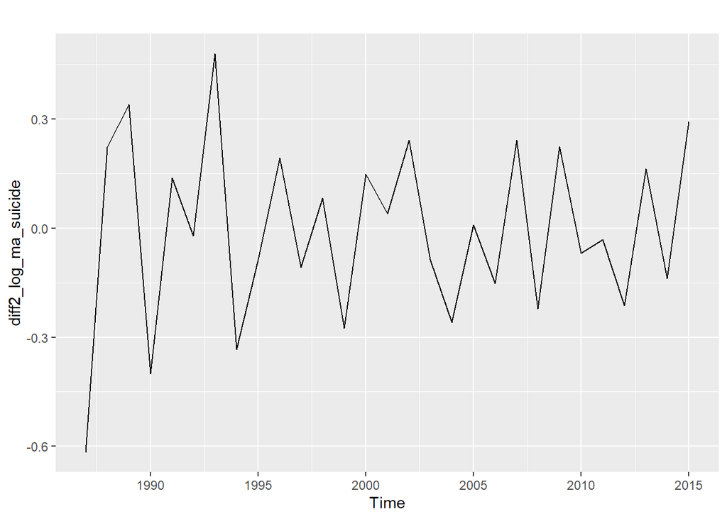

```r
diff2_log_ma_suicide <- diff(diff_log_ma_suicide,differences=1)
diff2_log_fe_suicide <- diff(diff_log_fe_suicide,differences=1)
autoplot(diff2_log_ma_suicide)
```

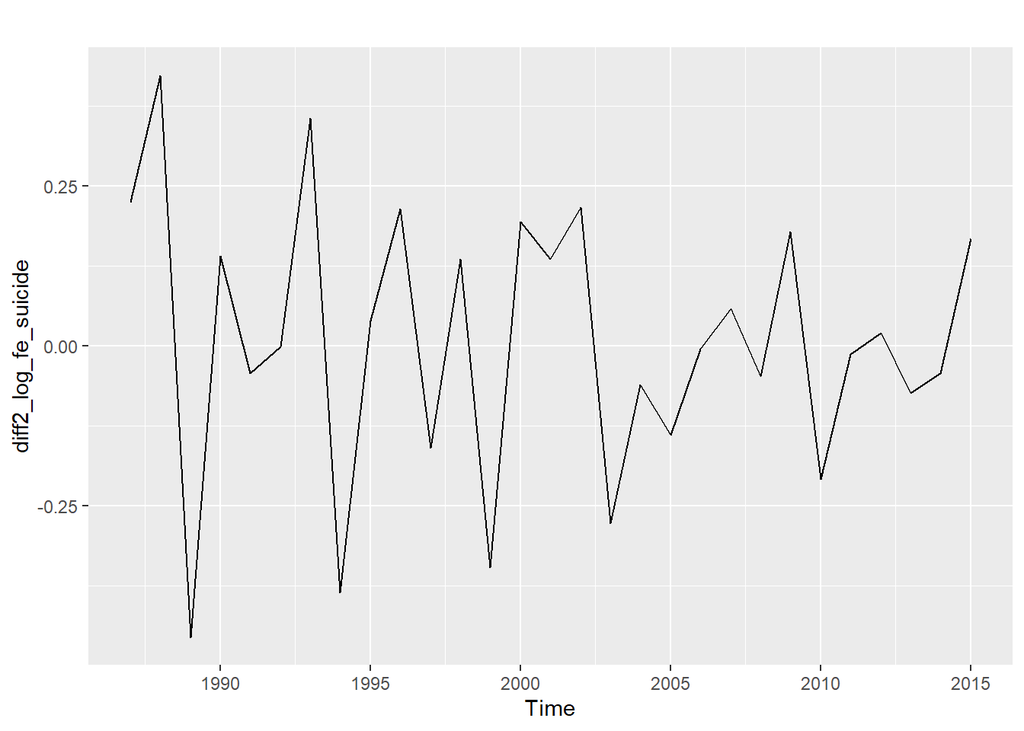

```r
autoplot(diff2_log_fe_suicide)
```

```r
adf.test(diff2_log_ma_suicide)
```

```
##
##  Augmented Dickey-Fuller Test
##
## data:  diff2_log_ma_suicide
## Dickey-Fuller = -4.5461, Lag order = 3, p-value = 0.01
## alternative hypothesis: stationary
```

```r
adf.test(diff2_log_fe_suicide)
```

```
##
##  Augmented Dickey-Fuller Test
##
## data:  diff2_log_fe_suicide
## Dickey-Fuller = -5.6528, Lag order = 3, p-value = 0.01
## alternative hypothesis: stationary
```

정상시계열임을 확인할 수 있습니다.

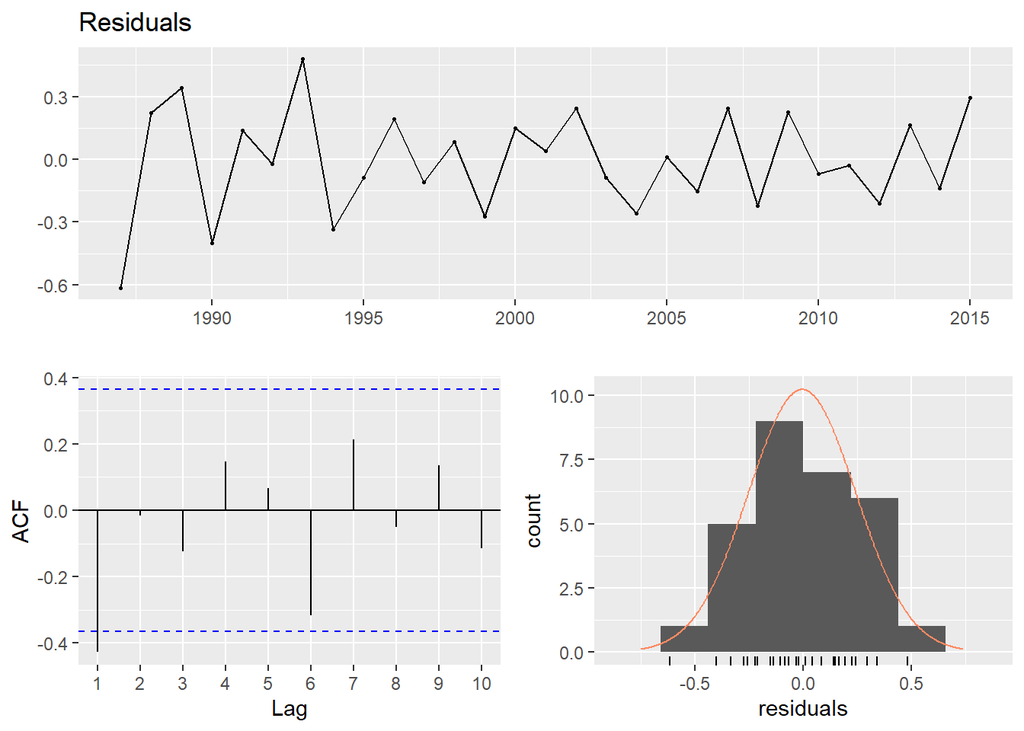

```r
checkresiduals(diff2_log_ma_suicide)
```

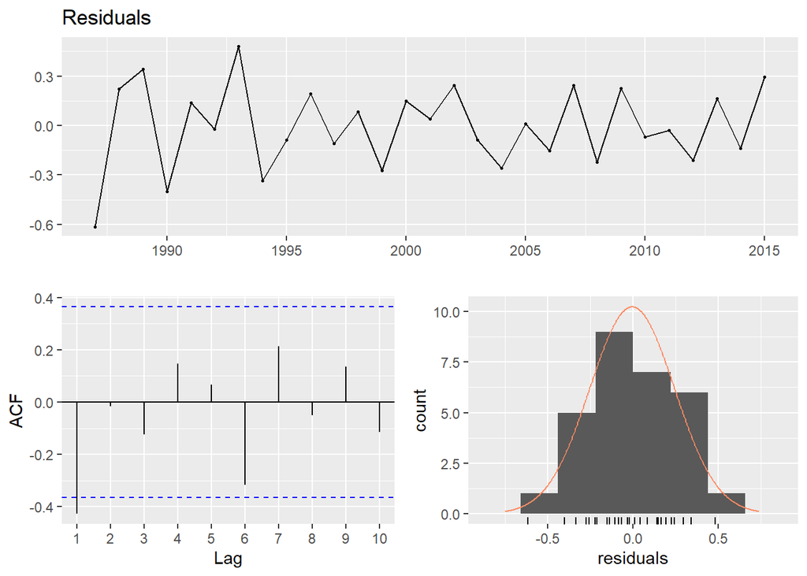

```r
checkresiduals(diff2_log_ma_suicide)
```

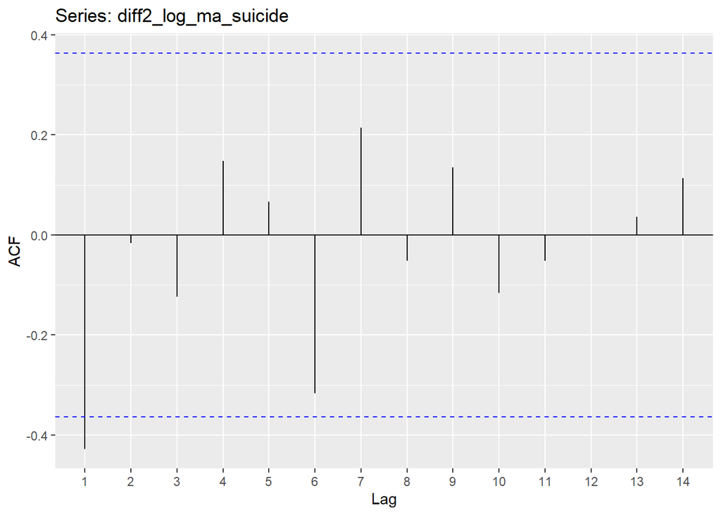

```r
ggAcf(diff2_log_ma_suicide)
```

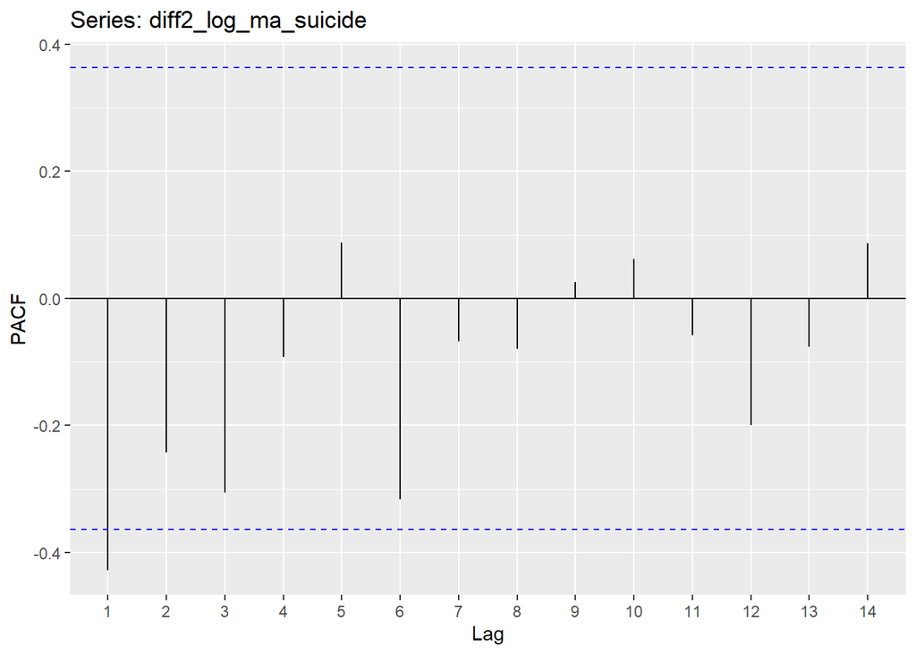

```r
ggPacf(diff2_log_ma_suicide)
```

acf와 pacf를 확인한 결과 ARIMA(1,2,1) 모형을 사용하면 될 것이다.

auto.arima에서 추천한 모형은 ARIMA(0,2,1)이다.

```r
auto.arima(diff2_log_ma_suicide)
```

```
## Series: diff2_log_ma_suicide
## ARIMA(0,0,1) with zero mean
##
## Coefficients:
##           ma1
##       -0.9243
## s.e.   0.1865
##
## sigma^2 estimated as 0.03303:  log likelihood=7.85
## AIC=-11.7   AICc=-11.24   BIC=-8.96
```

```r
arima(diff2_log_ma_suicide,order=c(1,0,1))
```

```
##
## Call:
## arima(x = diff2_log_ma_suicide, order = c(1, 0, 1))
##
## Coefficients:
##           ar1     ma1  intercept
##       -0.0060  -1.000    -0.0032
## s.e.   0.1923   0.145     0.0036
##
## sigma^2 estimated as 0.02956:  log likelihood = 8.2,  aic = -8.4
```

한시점만 예측을 해보자

```r
forecast(auto.arima(diff2_log_ma_suicide),1)
```

```
##      Point Forecast      Lo 80     Hi 80      Lo 95     Hi 95
## 2016    -0.09111712 -0.3241894 0.1419551 -0.4475704 0.2653361
```

```r
forecast(arima(diff2_log_ma_suicide,order=c(1,0,1)),1)
```

```
##      Point Forecast      Lo 80     Hi 80      Lo 95     Hi 95
## 2016     -0.1182791 -0.3422713 0.1057132 -0.4608456 0.2242875
```

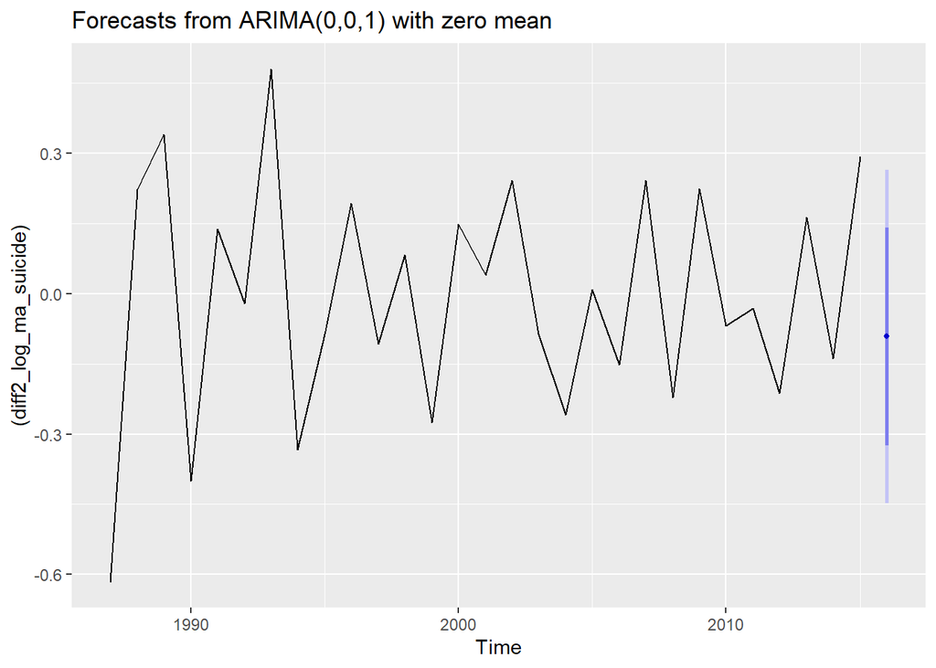

```r
autoplot(forecast(auto.arima((diff2_log_ma_suicide)),h=1))
```

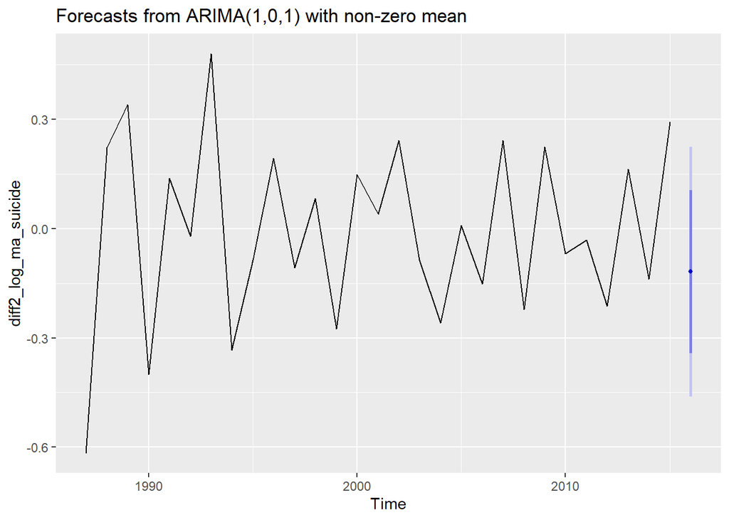

```r
autoplot(forecast(arima(diff2_log_ma_suicide,order=c(1,0,1)),h=1))
```

차분한 값들을 원래대로 돌려봅니다.  
$point forecast = y_t -2y_{t-1} +y_{t-2}$ $y_t = point forecast + 2y_{t-1} -y_{t_2}$

```r
(forecast(auto.arima(diff2_log_ma_suicide), 1)[["lower"]] + 2*log_ma_suicide[length(log_ma_suicide)] - log_ma_suicide[(length(log_ma_suicide)-1)])^exp(1)
```

```
## Time Series:
## Start = 2016
## End = 2016
## Frequency = 1
##           80%      95%
## 2016 68.92606 64.16313
```

```r
(forecast(auto.arima(diff2_log_ma_suicide), 1)[["upper"]] + 2*log_ma_suicide[length(log_ma_suicide)] - log_ma_suicide[(length(log_ma_suicide)-1)])^exp(1)
```

```
## Time Series:
## Start = 2016
## End = 2016
## Frequency = 1
##           80%      95%
## 2016 88.91863 94.75758
```